# Developing Data Products

Salim Virani  
April 10th 2017

### Idea

This project showcases the use of Shiny application to interactively explore application of clustering algorithmon a given dataset when different predictors are selected from the dataset to predict the cluster.

The Shiny app allows the user to interactively compare the actual group of the data point to that predicted by clustering algorithm

### Example Dataset

The dataset selected is the IRIS dataset. The IRIS dataset has the following columns. The goal of the application is to predict the Species column using any 2 of the other 4 columns as predictors.

```
  Sepal.Length Sepal.Width Petal.Length Petal.Width Species
1          5.1         3.5          1.4         0.2  setosa
2          4.9         3.0          1.4         0.2  setosa
3          4.7         3.2          1.3         0.2  setosa
4          4.6         3.1          1.5         0.2  setosa
5          5.0         3.6          1.4         0.2  setosa
6          5.4         3.9          1.7         0.4  setosa
```

### Example Plot 1

This plot shows one example of a plot that the app can show interactively by the shiny app. It can be seen that while Sertosa can be easily isolated using these two predictors, the other two species overlap

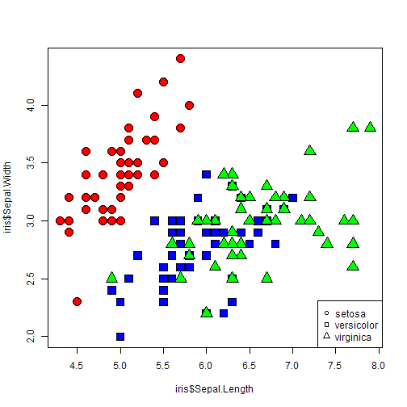

### Example Plot 2

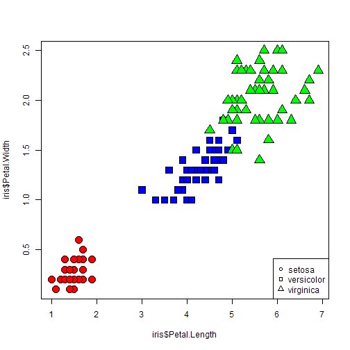